# Nonlinear Mixed Models and Random Regression

mixedFlowR tutorial series

# 1 Purpose

Many agronomic processes are intrinsically nonlinear: plant growth, germination, decomposition, nutrient uptake, dose response, and saturation. A polynomial can approximate curvature, but a mechanistic or phenomenological nonlinear function often yields parameters with clearer biological meaning.

This vignette develops logistic and Gompertz growth models, a four-parameter dose-response model, a generic nonlinear mixed-model interface, and polynomial random regression curves.

# 2 1. Learning objectives

You will learn to:

- recognize when a nonlinear function is preferable to a high-order polynomial;
- fit logistic and Gompertz growth mixed models;
- interpret asymptote and timing parameters;
- fit a four-parameter logistic dose-response mixed model;
- provide pooled starting values;
- use the generic `mixed_nonlinear()` interface;
- fit random regression curves;
- distinguish nonlinear fixed structure from random trajectory heterogeneity.

# 3 2. Growth teaching data

```r
library(mixedFlowR)
g <- mixed_data("growth")
head(g)
```

```
#>   plant treatment time   biomass
#> 1   P01   control    0 -2.136512
#> 2   P01   control    5  4.593750
#> 3   P01   control   10 11.163763
#> 4   P01   control   15 26.031429
#> 5   P01   control   20 42.131653
#> 6   P01   control   25 61.292855
```

Plot observed trajectories.

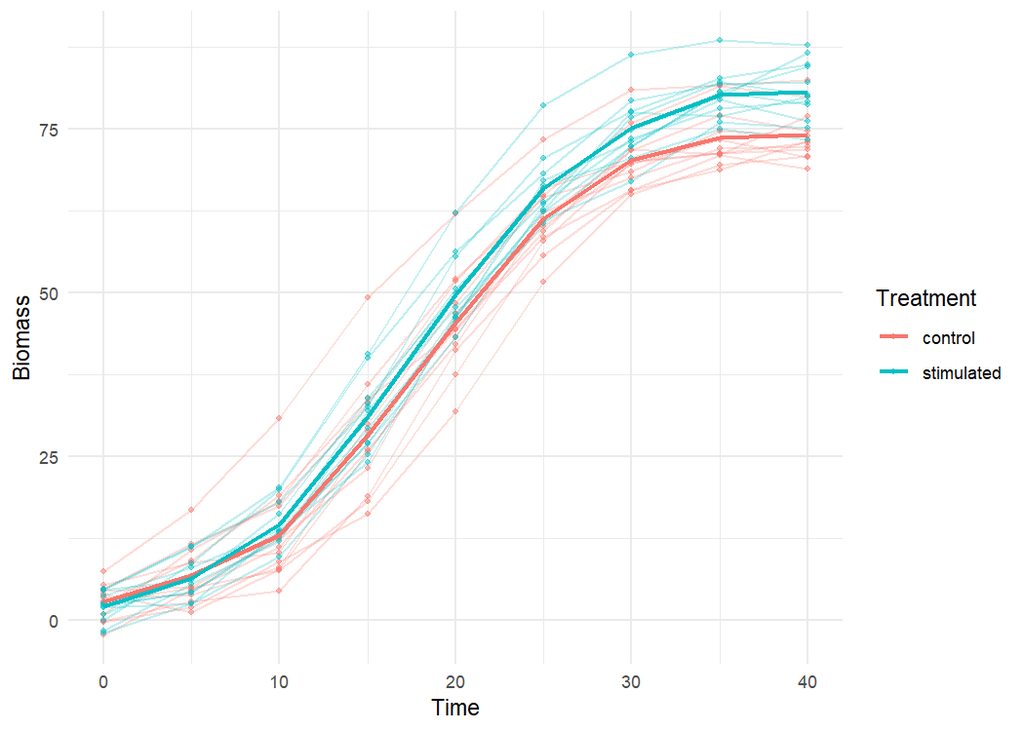

```r
if (requireNamespace("ggplot2", quietly = TRUE)) {
  ggplot2::ggplot(g, ggplot2::aes(time, biomass, group = plant, colour = treatment)) +
    ggplot2::geom_line(alpha = 0.25) +
    ggplot2::geom_point(alpha = 0.45, size = 1) +
    ggplot2::stat_summary(
      ggplot2::aes(group = treatment),
      fun = mean,
      geom = "line",
      linewidth = 1.1
    ) +
    ggplot2::theme_minimal(base_size = 11) +
    ggplot2::labs(x = "Time", y = "Biomass", colour = "Treatment")
}
```

The S-shaped trajectory motivates logistic or Gompertz growth functions.

# 4 3. Logistic growth mixed model

```r
if (requireNamespace("nlme", quietly = TRUE)) {
  logis_fit <- mixed_growth(
    data     = g,
    response = "biomass",
    time     = "time",
    group    = "plant",
    model    = "logistic"
  )

  logis_fit
}
```

```
#> $call
#> mixed_growth(data = g, response = "biomass", time = "time", group = "plant",
#>     model = "logistic")
#>
#> $engine
#> [1] "nlme"
#>
#> $model
#> Nonlinear mixed-effects model fit by maximum likelihood
#>   Model: biomass ~ SSlogis(time, Asym, xmid, scal)
#>   Data: ..mf_data
#>   Log-likelihood: -621.7922
#>   Fixed: Asym + xmid + scal ~ 1
#>      Asym      xmid      scal
#> 78.932134 17.656150  5.149881
```

[output cut: 252 more lines]

The implementation uses the self-starting logistic form with parameters `Asym`, `xmid`, and `scal`, with a random effect on `Asym` in the current wrapper.

# 5 4. Biological interpretation of logistic parameters

- `Asym`: asymptotic response level;
- `xmid`: time associated with the curve midpoint;
- `scal`: controls transition steepness/time scale.

Because these are nonlinear parameters, their meaning is usually more interpretable than coefficients of a fourth-order polynomial.

# 6 5. Gompertz growth mixed model

```r
if (requireNamespace("nlme", quietly = TRUE)) {
  gomp_fit <- mixed_growth(
    data     = g,
    response = "biomass",
    time     = "time",
    group    = "plant",
    model    = "gompertz"
  )

  gomp_fit
}
```

```
#> $call
#> mixed_growth(data = g, response = "biomass", time = "time", group = "plant",
#>     model = "gompertz")
#>
#> $engine
#> [1] "nlme"
#>
#> $model
#> Nonlinear mixed-effects model fit by maximum likelihood
#>   Model: biomass ~ SSgompertz(time, Asym, b2, b3)
#>   Data: ..mf_data
#>   Log-likelihood: -643.2513
#>   Fixed: Asym + b2 + b3 ~ 1
#>       Asym         b2         b3
#> 83.5935304  5.7200669  0.8885488
```

[output cut: 252 more lines]

Logistic and Gompertz curves differ in symmetry around the inflection region. Choose based on biological plausibility and model adequacy, not only fit score.

# 7 6. Compare growth candidates

```r
if (exists("logis_fit") && exists("gomp_fit")) {
  mixed_compare(
    Logistic = logis_fit,
    Gompertz = gomp_fit,
    method = "information"
  )
}
```

```
#>      model engine                                     fixed npar    logLik
#> 1 Logistic   nlme biomass ~ SSlogis(time, Asym, xmid, scal)    5 -621.7922
#> 2 Gompertz   nlme  biomass ~ SSgompertz(time, Asym, b2, b3)    5 -643.2513
#>        AIC      BIC
#> 1 1253.584 1270.461
#> 2 1296.503 1313.379
```

Inspect residuals and parameter plausibility before declaring a preferred curve.

# 8 7. Growth diagnostics

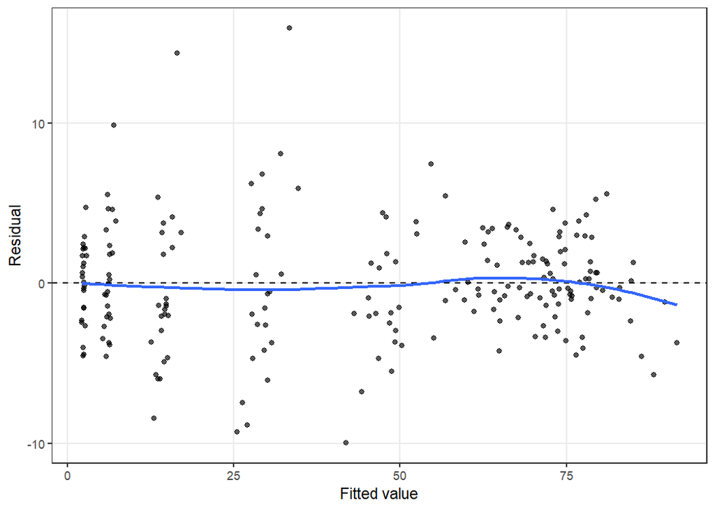

```r
if (exists("logis_fit")) {
  mixed_diagnose(logis_fit)
  mixed_plot(logis_fit, type = "residuals")
}
```

Nonlinear convergence can depend on starting values and parameter scaling. A converged model can still be biologically implausible.

# 9 8. Generic nonlinear mixed model with nlme

Obtain pooled starting values.

```r
if (requireNamespace("nlme", quietly = TRUE)) {
  st <- stats::getInitial(
    biomass ~ SSlogis(time, Asym, xmid, scal),
    data = g
  )
  st
}
```

```
#>      Asym      xmid      scal
#> 79.101632 17.745591  5.145974
```

Use the generic wrapper.

```r
if (requireNamespace("nlme", quietly = TRUE)) {
  generic_logis <- mixed_nonlinear(
    biomass ~ SSlogis(time, Asym, xmid, scal),
    data   = g,
    engine = "nlme",
    fixed  = Asym + xmid + scal ~ 1,
    random = Asym ~ 1,
    groups = ~ plant,
    start  = st
  )
}
```

This interface is appropriate when the predefined growth/dose wrappers are too restrictive.

# 10 9. Generic nonlinear mixed model with lme4

```r
if (requireNamespace("lme4", quietly = TRUE)) {
  st_lme4 <- stats::getInitial(
    biomass ~ SSlogis(time, Asym, xmid, scal),
    data = g
  )

  lme4_nl <- mixed_nonlinear(
    biomass ~ SSlogis(time, Asym, xmid, scal) ~ (Asym | plant),
    data   = g,
    engine = "lme4",
    start  = st_lme4
  )
}
```

Backend formula conventions differ; the orchestration layer does not erase those statistical and syntactic differences.

# 11 10. Dose-response teaching data

```r
dd <- mixed_data("dose_response")
head(dd)
```

```
#>   unit block dose response
#> 1  U01    B1    0 26.50516
#> 2  U01    B1   10 25.97178
#> 3  U01    B1   25 34.83542
#> 4  U01    B1   50 51.74161
#> 5  U01    B1  100 79.44006
#> 6  U01    B1  200 82.14707
```

Observed means:

```r
aggregate(response ~ dose, dd, mean)
```

```
#>   dose response
#> 1    0 22.08147
#> 2   10 25.32594
#> 3   25 34.46771
#> 4   50 54.74557
#> 5  100 80.06959
#> 6  200 82.35157
```

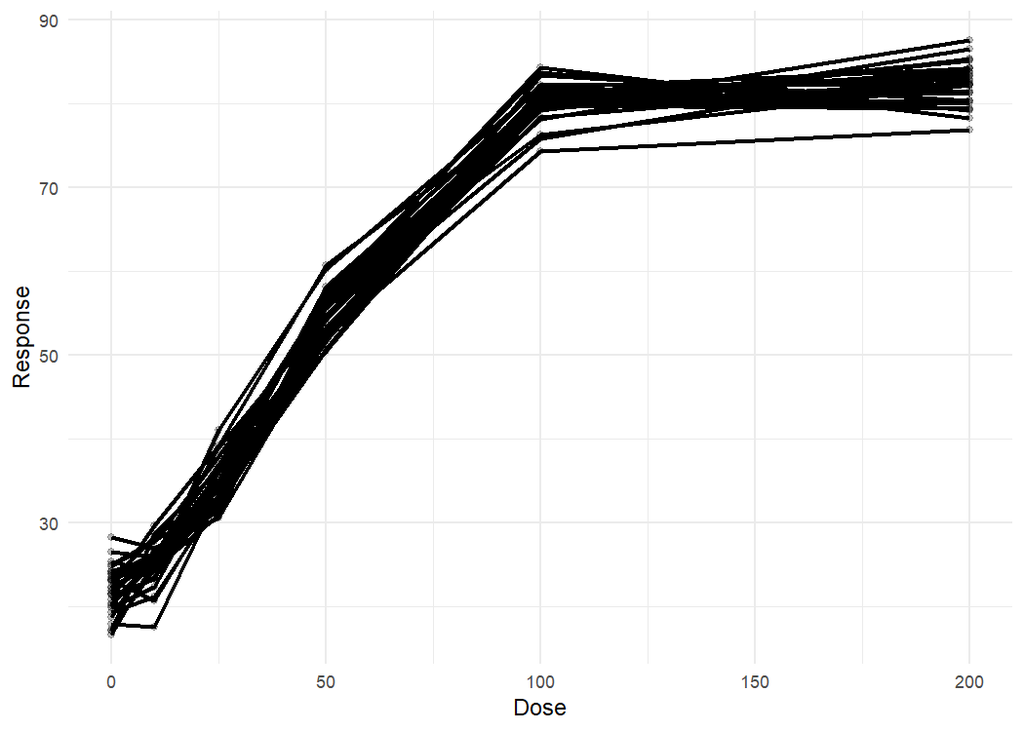

```r
if (requireNamespace("ggplot2", quietly = TRUE)) {
  ggplot2::ggplot(dd, ggplot2::aes(dose, response, group = unit)) +
    ggplot2::geom_line(alpha = 0.12) +
    ggplot2::geom_point(alpha = 0.25) +
    ggplot2::stat_summary(fun = mean, geom = "line", linewidth = 1.1, colour = "black") +
    ggplot2::theme_minimal(base_size = 11) +
    ggplot2::labs(x = "Dose", y = "Response")
}
```

# 12 11. Four-parameter dose-response mixed model

```r
if (requireNamespace("nlme", quietly = TRUE)) {
  dose_fit <- mixed_dose_response(
    data     = dd,
    response = "response",
    dose     = "dose",
    group    = "unit"
  )

  dose_fit
}
```

```
#> $call
#> mixed_dose_response(data = dd, response = "response", dose = "dose",
#>     group = "unit")
#>
#> $engine
#> [1] "nlme"
#>
#> $model
#> Nonlinear mixed-effects model fit by maximum likelihood
#>   Model: response ~ SSfpl(dose, A, B, xmid, scal)
#>   Data: ..mf_data
#>   Log-likelihood: -419.6215
#>   Fixed: A + B + xmid + scal ~ 1
#>        A        B     xmid     scal
#> 16.54834 82.66435 43.90004 18.39605
```

[output cut: 216 more lines]

The current wrapper uses `SSfpl` with a random effect on parameter `A`.

# 13 12. User-supplied starts

```r
if (requireNamespace("nlme", quietly = TRUE)) {
  dose_start <- stats::getInitial(
    response ~ SSfpl(dose, A, B, xmid, scal),
    data = dd
  )

  dose_fit_start <- mixed_dose_response(
    dd,
    response = "response",
    dose = "dose",
    group = "unit",
    start = dose_start
  )
}
```

Starting values should be plausible and reproducible. If a nonlinear fit converges only from highly specific starts, investigate parameter identifiability.

# 14 13. Dose-response interpretation

Potential targets include:

- lower and upper asymptotes;
- midpoint dose;
- transition scale/steepness;
- predicted effective doses derived from the curve;
- between-unit variation in curve parameters.

Do not extrapolate a toxicity or optimum claim beyond the experimental dose range without external biological support.

# 15 14. Random regression curves

Random regression approximates trajectories with polynomials and allows coefficients to vary among units.

```r
z <- mixed_data("longitudinal")

if (requireNamespace("lme4", quietly = TRUE)) {
  rr1 <- mixed_random_curve(
    response = "height",
    time     = "time",
    data     = z,
    group    = "subject",
    degree   = 1,
    fixed    = "treatment"
  )
}
```

Quadratic random regression:

```r
if (requireNamespace("lme4", quietly = TRUE)) {
  rr2 <- mixed_random_curve(
    response = "height",
    time     = "time",
    data     = z,
    group    = "subject",
    degree   = 2,
    fixed    = "treatment"
  )
}
```

# 16 15. Compare random regression degrees

```r
if (exists("rr1") && exists("rr2")) {
  mixed_compare(
    linear    = rr1,
    quadratic = rr2,
    method = "information"
  )
}
```

```
#>       model engine                                          fixed npar
#> 1    linear   lme4 height ~ treatment + poly(time, 1, raw = TRUE)    7
#> 2 quadratic   lme4 height ~ treatment + poly(time, 2, raw = TRUE)   11
#>      logLik      AIC      BIC
#> 1 -355.6064 725.2128 747.5635
#> 2 -354.9114 731.8229 766.9454
```

A higher polynomial degree increases random-effect dimensionality rapidly. Diagnose singularity and covariance estimation carefully.

# 17 16. Nonlinear mixed model versus random regression

**Nonlinear mixed model**

- imposes a named biological/phenomenological curve;
- parameters often have direct meaning;
- can be sensitive to starts and identifiability.

**Random regression**

- approximates trajectories flexibly with polynomial basis functions;
- useful for heterogeneous longitudinal trajectories;
- parameters themselves may be less biologically intuitive.

# 18 17. Bayesian nonlinear template

`mixed_nonlinear()` can delegate a nonlinear `brms` formula to `brms`.

```r
bf_growth <- brms::bf(
  biomass ~ Asym / (1 + exp((xmid - time) / scal)),
  Asym ~ 1 + (1 | plant),
  xmid ~ 1,
  scal ~ 1,
  nl = TRUE
)

bayes_growth <- mixed_nonlinear(
  bf_growth,
  data = g,
  engine = "brms",
  prior = nonlinear_priors,  # define priors on biologically interpretable parameters first
  chains = 4,
  iter = 4000,
  seed = 260818
)
```

Priors on nonlinear parameters need especially careful scale interpretation.

# 19 18. Reporting nonlinear models

Report:

- curve equation or named self-start function;
- fixed parameter structure;
- random parameter structure;
- starting-value method;
- convergence diagnostics;
- parameter estimates with uncertainty;
- derived quantities such as asymptote or midpoint;
- observed data with fitted curves;
- experimental range and extrapolation limits.

# 20 19. Exercises

1. Compare logistic and Gompertz fits visually and numerically.
2. Fit a logistic model to one treatment subset and compare parameter interpretation with the pooled model.
3. Fit degree-1 and degree-2 random regression curves and inspect singularity.
4. Explain why a high-order polynomial optimum can be less biologically meaningful than a dose-response parameter.

# 21 20. Key take-home messages

- Nonlinear functions can provide biologically meaningful parameters.
- Starting values and parameter identifiability matter.
- A lower AIC does not make a biologically implausible curve acceptable.
- Random regression and nonlinear mixed models solve related but distinct trajectory problems.
- Avoid extrapolation beyond experimental support.

# 22 21. What comes next

Stage 4 begins with `12-spatial-field-trials.Rmd`, followed by multi-environment trials, publication outputs, and teaching tours.